# whales_project

### Data Augmentation

Feature Standardization

```python
## Data augmentation
def feature_augmentation(X, y, exples_to_add ):
    # convert from int to float
    #X = X.astype('float32')

    # define data preparation
    datagen_fea = ImageDataGenerator(featurewise_center=True,
                               featurewise_std_normalization=True)
    # fit parameters from data
    datagen_fea.fit(X)
    # configure batch size and retrieve one batch of images
    for X_batch, y_batch in datagen_fea.flow(X, y, batch_size=exples_to_add):
        # create a grid of 3x3 images
        #for i in range(0, 9):
        #	plt.subplot(330 + 1 + i)
        #	plt.imshow(X_batch[i])
        # show the plot
        #plt.show()
        break
    return(X_batch, y_batch)
```

```python
def conc(X_cleaned, y_cleaned, X_batch, y_batch):
    X_cleaned = np.concatenate((X_cleaned, X_batch), axis=0)
    y_cleaned = np.concatenate((y_cleaned, y_batch), axis=0)
    return(X_cleaned, y_cleaned)
```

Random rotations

```python
def rotation_augmentation(X, y , exples_to_add):
    #X = X.astype('float32')
    # define data preparation
    datagen_rot = ImageDataGenerator(rotation_range=90)
    # fit parameters from data
    datagen_rot.fit(X)
    # configure batch size and retrieve one batch of images
    for X_batch, y_batch in datagen_rot.flow(X, y, batch_size =exples_to_add):
        # create a grid of 3x3 images
        #for i in range(0, 9):
        #	plt.subplot(330 + 1 + i)
        #	plt.imshow(X_batch[i])
        # show the plot
        #plt.show()
        break
    return(X_batch, y_batch)
```

Random zoom

```python
def zoom_augmentation(X, y , exples_to_add):
    #X = X.astype('float32')
    # define data preparation
    datagen_zoom = ImageDataGenerator(zoom_range=0.2)
    # fit parameters from data
    datagen_zoom.fit(X)
    # configure batch size and retrieve one batch of images
    for X_batch, y_batch in datagen_zoom.flow(X, y, batch_size=exples_to_add):
        # create a grid of 3x3 images
        #for i in range(0, 9):
        #	plt.subplot(330 + 1 + i)
        #	plt.imshow(X_batch[i])
        # show the plot
        #plt.show()
        break
    return(X_batch, y_batch)
```

Random Flip

```python
def flip_augmentation(X, y , exples_to_add):
    #X = X.astype('float32')
    # define data preparation
    datagen_flip = ImageDataGenerator(horizontal_flip=True,
                                               vertical_flip=True)
    # fit parameters from data
    datagen_flip.fit(X)
    # configure batch size and retrieve one batch of images
    for X_batch, y_batch in datagen_flip.flow(X, y, batch_size=exples_to_add):
        # create a grid of 3x3 images
        #for i in range(0, 9):
        #	plt.subplot(330 + 1 + i)
        #	plt.imshow(X_batch[i])
        # show the plot
        #plt.show()
        break
    return(X_batch, y_batch)
```

```python
def all_augmentation(X,y, exples_to_add):

    # convert from int to float
    #X= X.astype('float32')

    # define data preparation
    datagen_all = ImageDataGenerator( rotation_range=40,
                                               width_shift_range=0.2,
                                               height_shift_range=0.2,
                                               shear_range=0.2,
                                               zoom_range=0.2,
                                               fill_mode='nearest',
                                               horizontal_flip=True,
                                               vertical_flip=True)
    # fit parameters from data
    datagen_all.fit(X)
    # configure batch size and retrieve one batch of images
    for X_batch, y_batch in datagen_all.flow(X, y, batch_size=exples_to_add):
        # create a grid of 3x3 images
        #for i in range(0, 9):
        #	plt.subplot(330 + 1 + i)
        #	plt.imshow(X_batch[i])
        # show the plot
        #plt.show()
        break
    return(X_batch, y_batch)
```

```python
def augment(X_cleaned, y_cleaned, portion_x, portion_y, exples_to_add):

    nb = exples_to_add // 5
    final = exples_to_add - nb * 4

    #portion_x = portion_x.astype('float32')

    X_batch, y_batch = feature_augmentation(portion_x,portion_y, nb)
    X_cleaned, y_cleaned = conc(X_cleaned, y_cleaned, X_batch, y_batch)
    print('After feature augmentation',X_cleaned.shape, y_cleaned.shape)

    X_batch_rot, y_batch_rot = rotation_augmentation(portion_x,portion_y, nb)
    X_cleaned, y_cleaned = conc(X_cleaned, y_cleaned, X_batch_rot, y_batch_rot)
    print('After rotation_augmentation ',X_cleaned.shape, y_cleaned.shape)

    X_batch_zoom, y_batch_zoom = zoom_augmentation(portion_x,portion_y, nb)
    X_cleaned, y_cleaned = conc(X_cleaned, y_cleaned, X_batch_zoom, y_batch_zoom)
    print('After zoom_augmentation ',X_cleaned.shape, y_cleaned.shape)


    X_batch_flip, y_batch_flip = flip_augmentation(portion_x,portion_y, nb)
    X_cleaned, y_cleaned = conc(X_cleaned, y_cleaned, X_batch, y_batch)
    print('After flip_augmentation ',X_cleaned.shape, y_cleaned.shape)

    X_batch_all, y_batch_all = all_augmentation(portion_x,portion_y, final)
    X_cleaned, y_cleaned = conc(X_cleaned, y_cleaned, X_batch, y_batch)
    print('After several augmentation ',X_cleaned.shape, y_cleaned.shape)
    return(X_cleaned, y_cleaned)
```

### Data augmentation for the whole dataset

```python
X_original = X_cleaned
y_original = y_cleaned
```

```python
X_cleaned, y_cleaned = augment(X_cleaned, y_cleaned, X_cleaned, y_cleaned, 5000)
```

Splitting to train and validation sets

```python
nb_samples = X_cleaned.shape[0]
train_size = nb_samples*0.8


X_cleaned_train = X_cleaned[:train_size]
y_cleaned_train = y_cleaned[:train_size]

X_cleaned_val = X_cleaned[train_size:]
y_cleaned_val = y_cleaned[train_size:]
```

### Load pre-trained model and compile: vgg16

#### Load the model

```python
#Load the VGG model
vgg_conv = vgg16.VGG16(weights='imagenet', include_top=False, input_shape=(100, 100, 3))
```

```python
# Freeze the layers except the last 3 layers
for layer in vgg_conv.layers[:-3]:
    layer.trainable = False

# Check the trainable status of the individual layers
for layer in vgg_conv.layers:
    print(layer, layer.trainable)
```

```
<keras.engine.input_layer.InputLayer object at 0x7f5c3d4ff3c8> False
<keras.layers.convolutional.Conv2D object at 0x7f5c3d8a8a20> False
<keras.layers.convolutional.Conv2D object at 0x7f5c3d8a8908> False
<keras.layers.pooling.MaxPooling2D object at 0x7f5c3d4ff978> False
<keras.layers.convolutional.Conv2D object at 0x7f5c3d4ff748> False
<keras.layers.convolutional.Conv2D object at 0x7f5c3d4b9630> False
<keras.layers.pooling.MaxPooling2D object at 0x7f5c3d4d21d0> False
<keras.layers.convolutional.Conv2D object at 0x7f5c3d4d2f60> False
<keras.layers.convolutional.Conv2D object at 0x7f5c3d484278> False
<keras.layers.convolutional.Conv2D object at 0x7f5c3d49b550> False
<keras.layers.pooling.MaxPooling2D object at 0x7f5c3d4324a8> False
<keras.layers.convolutional.Conv2D object at 0x7f5c3d432f60> False
<keras.layers.convolutional.Conv2D object at 0x7f5c3d468278> False
<keras.layers.convolutional.Conv2D object at 0x7f5c3d3fd550> False
<keras.layers.pooling.MaxPooling2D object at 0x7f5c3d4144a8> False
<keras.layers.convolutional.Conv2D object at 0x7f5c3d414f60> False
<keras.layers.convolutional.Conv2D object at 0x7f5c3d3ce278> True
<keras.layers.convolutional.Conv2D object at 0x7f5c3d3de550> True
<keras.layers.pooling.MaxPooling2D object at 0x7f5c3d37d4a8> True
```

```python
# Create the model
model = models.Sequential()

# Add the vgg convolutional base model
model.add(vgg_conv)

# Add new layers
model.add(layers.Flatten())
model.add(layers.Dense(4000, activation='relu'))
model.add(layers.Dropout(0.75))
model.add(layers.Dense(nb_classes, activation='softmax'))

# Show a summary of the model. Check the number of trainable parameters
model.summary()
```

```
_________________________________________________________________
Layer (type)                 Output Shape              Param #
=================================================================
vgg16 (Model)                (None, 3, 3, 512)         14714688
_________________________________________________________________
flatten_2 (Flatten)          (None, 4608)              0
_________________________________________________________________
dense_3 (Dense)              (None, 4000)              18436000
_________________________________________________________________
dropout_2 (Dropout)          (None, 4000)              0
_________________________________________________________________
dense_4 (Dense)              (None, 5004)              20021004
=================================================================
Total params: 53,171,692
Trainable params: 43,176,620
Non-trainable params: 9,995,072
_________________________________________________________________
```

#### Compile and validate

```python
# Compile the model
model.compile(loss='categorical_crossentropy',
              optimizer=optimizers.Adadelta(),
              metrics=['categorical_accuracy','acc'])
# Train the model
#history = model.fit_generator(
#      train_generator,
#      steps_per_epoch=train_generator.samples/train_generator.batch_size ,
#      epochs=30,
#      validation_data=validation_generator,
#      validation_steps=validation_generator.samples/validation_generator.batch_size,
#      verbose=1)
epochs=100
history=model.fit(X_cleaned, y_cleaned,
              batch_size=100,
              epochs=epochs,
              shuffle=True)

# Save the model
#model.save('small_last4.h5')
```

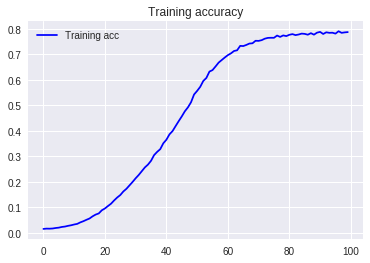

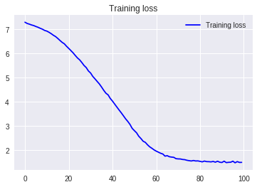

```python
acc = history.history['acc']
loss = history.history['loss']

epochs = range(len(acc))

plt.plot(epochs, acc, 'b', label='Training acc')
plt.title('Training accuracy')
plt.legend()

plt.figure()

plt.plot(epochs, loss, 'b', label='Training loss')
plt.title('Training loss')
plt.legend()

plt.show()
```

#### Evaluation and Prediction

```python
X_test = prepareImages(df_submission, df_submission.shape[0],image_size=100)
X_test /= 255
```

```
Preparing images
Processing image:  1 ,  00028a005.jpg
Processing image:  501 ,  0f9219c40.jpg
Processing image:  1001 ,  1ea95c247.jpg
Processing image:  1501 ,  2fe4ec2d5.jpg
Processing image:  2001 ,  404206f77.jpg
Processing image:  2501 ,  4fc69fd82.jpg
Processing image:  3001 ,  5ffc2d300.jpg
Processing image:  3501 ,  7042be267.jpg
Processing image:  4001 ,  801c6a722.jpg
Processing image:  4501 ,  906aa36c8.jpg
Processing image:  5001 ,  a0d337cdc.jpg
Processing image:  5501 ,  b1a4e4c18.jpg
Processing image:  6001 ,  c0b378682.jpg
Processing image:  6501 ,  cfe9d9d04.jpg
Processing image:  7001 ,  e00620fc3.jpg
Processing image:  7501 ,  f1b504951.jpg
```

```python
y_pred=model.predict(X_test)
```

```python
best_4_indexes = np.array([y_pred[i].argsort()[-4:][::-1] for i in range(y_pred.shape[0])])
```

```python
best_4_indexes
```

```
array([[4602, 3231,  143, 3514],
       [1276, 2048,  977, 4354],
       [3825, 1434,  309, 2873],
       ...,
       [2097, 3727, 3373, 2585],
       [1110, 1029, 2132, 4875],
       [4357, 4258,  517, 2224]])
```

```python
best_5 = np.array([" ".join(['new_whale']+list(label_encoder.inverse_transform(best_4_indexes[i]), axis=0)) for i in range (y_pred.shape[0])])
print(best_5.shape)
```

```
(7960,)
```

```python
d = {'Image': df_submission['Image'], 'Id': best_5}
df_final = pd.DataFrame(data=d)
df_final.to_csv('submit.csv',sep=',',columns=['Image','Id'] ,encoding='utf-8', index=False)
```

## Third Trial : still uneven classes ==> targeted data augmentation

Targeted data augmentation for the poor classes

Data Augmentation targeted to every class (to attend 73 per class)

```python
X_targeted_augmentation = X_original
y_targeted_augmentation = y_original
portion_x = X_original[:d[1]]
portion_y = y_original[:d[1]]
X_targeted_augmentation, y_targeted_augmentation = augment(X_targeted_augmentation,y_targeted_augmentation,portion_x,portion_y, (73-1))
```

```
After feature augmentation (15711, 100, 100, 3) (15711, 5004)
```

```python
X_targeted_augmentation = X_original
y_targeted_augmentation = y_original

sum_update = 0
print(X_original.shape, y_original.shape)
for i in range(1, 2):
    portion_x = X_original[sum_update:sum_update + d[i]]
    portion_y = y_original[sum_update:sum_update + d[i]]
    sum_update += d[i]
    X_targeted_augmentation, y_targeted_augmentation = augment(X_targeted_augmentation,y_targeted_augmentation,portion_x,portion_y, (73-i))
print(X_targeted_augmentation.shape, y_targeted_augmentation.shape)
```

Memory Leak problem with Keras while using Data generator: ImageDataGenerator flow function continue to increase the amount of memory usage which seems to be a common problem https://github.com/keras-team/keras/issues/5835 with the new version of keras

## Fourth Trial : threshold about new_whale prediction

fixing a threshold to add new_whale or not

```python
### We take the indices of the 5 biggest probabilities
#five_classes=np.argsort(y_pred,axis=1)[:,-5:]

# We transform the label of the class (the index of the column) into the former name of the class

#submission=np.empty((np.shape(y_pred)[0],5),dtype=object)
#for i in range (np.shape(y_pred)[0]):
#  submission[i]=np.flip(label_encoder.inverse_transform(five_classes[i]),axis=0)

#five_probabilities=np.zeros(np.shape(five_classes))
#for i in range(np.shape(five_classes)[0]):
#  five_probabilities[i]=y_pred[i,five_classes[i]] #We create the array with the five biggest probabilities for each images

#ecarts=np.zeros(np.shape(five_classes)[0])
#for i in range(np.shape(five_classes)[0]):
#  ecarts[i]=np.std(five_probabilities[i])


#threshold=np.sort(ecarts)[int(np.floor((30/100)*len(ecarts)))]

#new_whale_or_not=np.empty(np.shape(five_classes)[0])
#for i in range(np.shape(five_classes)[0]):
#  if np.std(five_probabilities[i])<=threshold:
#    new_whale_or_not[i]=True
#  else:
#    new_whale_or_not[i]=False

# Here we transform the array so that it is in the correct format when converted in a csv file

#submission_proper_format=np.empty((np.shape(y_pred)[0],2),dtype=object)
#for i in range (np.shape(y_pred)[0]):
#  if new_whale_or_not[i]==True:
#    submission_proper_format[i]=np.array([df_test["Image"][i],"new_whale"+" "+submission[i,0]+" "+submission[i,1]+" "+submission[i,2]+" "+submission[i,3]])
#  else:
#    submission_proper_format[i]=np.array([df_test["Image"][i],submission[i,0]+" "+"new_whale"+" "+submission[i,1]+" "+submission[i,2]+" "+submission[i,3]])
```